# gridabm: A Tool for 2D Cellular Automata and Agent-Based Models

The `gridabm` library provides tools for building, visualizing, and analyzing cellular automata and agent-based models that run on a 2D grid. This article describes the general workflow of the package and shows you how to build your own automata or analyze the ones implemented in this package.

Johannes Nakayama https://github.com/JohannesNakayama  
2022-06-13

## Installation

To install the `gridabm` library, you need the [`remotes` package](https://github.com/r-lib/remotes) to install it from Github. If you haven’t installed `remotes` yet, you can get it from CRAN:

```r
install.packages("remotes")
```

With the `remotes` package, you can install `gridabm` from Github:

```r
remotes::install_github("socialdynamicshub/gridabm")
```

## First Steps

The `gridabm` library lets you play around with [cellular automata](https://en.wikipedia.org/wiki/Cellular_automaton) on 2D grids. You can think of a grid just as a board of cells.

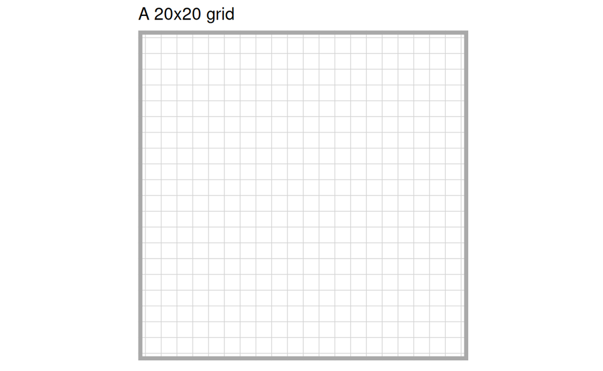

In the `gridabm` library, the grid is represented by a *matrix* whose entries only take on values from a set of distinct numeric states. Let’s for example create a matrix with the distinct states $0$ and $1$. Let’s say state $0$ means that the cell is empty, so we assign it the color white. State $1$ represents “something” on the board, we’ll assign it the color black.

Then the following matrix…

$$\begin{pmatrix}
0 & 0 & 0 & 0 & 1\\
0 & 1 & 0 & 0 & 1\\
1 & 0 & 0 & 0 & 1\\
0 & 1 & 1 & 0 & 0\\
1 & 0 & 0 & 0 & 0
\end{pmatrix}$$

… corresponds to the following plot:

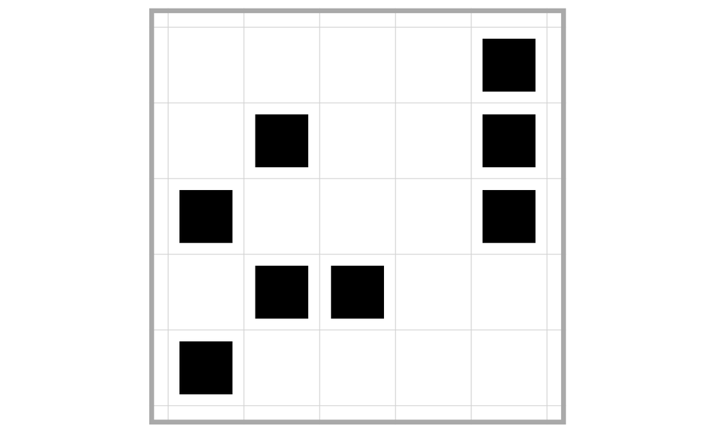

You can construct boards with more distinct states in the same way.

### Update Rules

Apart from a grid, a set of distinct states, and an initial state, we need a so-called **update rule**. In *agent-based modeling*, this is sometimes referred to as a **stepping function**. Usually, the update rules are defined at the cell/agent level, meaning that the state of an agent in the next iteration of the automaton is contingent on the states of its neighbors (or a subset of them).

What constitutes the neighborhood of an agent can be defined in different ways, but common neighborhoods are implemented in the package. For instance, the [Moore neighborhood](https://en.wikipedia.org/wiki/Moore_neighborhood) is simply the set of all adjacent cells, including diagonally adjacent ones.

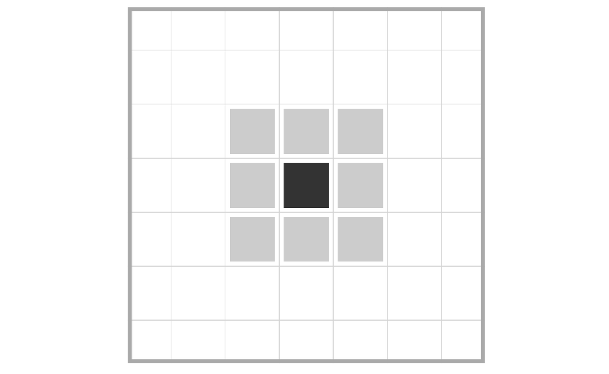

The Moore neighborhood of the darker cell is given by the lighter cells. To get the coordinates of a cell’s Moore neighborhood in the `gridabm` package, use the `get_moore_neighborhood` function.

```r
get_moore_neighborhood(i = 4, j = 5, axis_size = 20, periodic = TRUE)
```

`i` and `j` are the coordinates in the matrix, `axis_size` refers to the dimension of the matrix in either direction[^1], and the `periodic` parameter indicates whether the grid wraps around (i.e., more precisely, we’re dealing with a [torus](https://en.wikipedia.org/wiki/Torus)).

In the `gridabm` library, update rules are simply functions that

- take a matrix with numeric states,
- perform the update rule for each cell,
- and return the updated matrix.

The updated matrix should only contain values in the set of distinct states that we defined in the beginning.

Let’s examine this with a very simple example. We use a matrix with distinct states $0$ and $1$. Now we define an update rule as follows:

> Each cell adopts the state of the cell to its right.

We could implement this rule like this:

```r
left_shift_rule <- function(m) {
  axis_size <- dim(m)[1]
  m_upd <- m

  for (i in 1:axis_size) {
    for (j in 1:axis_size) {
      if (j < axis_size) {
        new_j <- j + 1
      } else {
        new_j <- 1
      }
      m_upd[i, j] <- m[i, new_j]
    }
  }

  return(m_upd)
}
```

Now, let’s create an initial state, run the simulation, and animate it. To change things up, let’s assign the color white to state $0$ and blue to state $1$

```r
left_shift_board <- matrix(
  sample(c(0, 1), prob = c(0.7, 0.3), replace = TRUE, size = 400),
  nrow = 20, ncol = 20
)
left_shift_results <- run_automaton(
  left_shift_board,
  steps = 100,
  stepfunc = left_shift_rule
)
animate_model_run(
  left_shift_results,
  marker_size = 5,
  color_scheme = c("white", "blue")
)
```

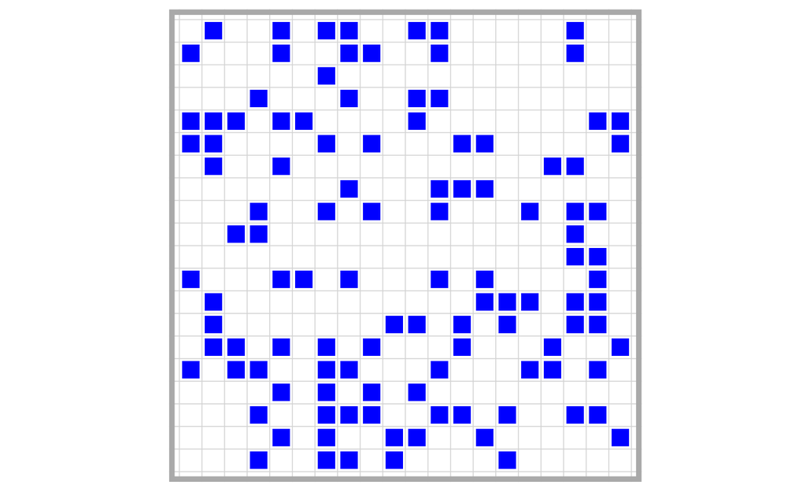

The code above is the general workflow of `gridabm`.

First, you create a state that you want to start from. It’s a simple `matrix` with several distinct states.

```r
left_shift_board <- matrix(
  sample(c(0, 1), prob = c(0.7, 0.3), replace = TRUE, size = 400),
  nrow = 20, ncol = 20
)
```

Then, you run the automaton with the stepping function (`stepfunc`) that you defined before.

```r
left_shift_results <- run_automaton(
  left_shift_board, steps = 100, stepfunc = left_shift_rule
)
```

The results can be animated with the function `animate_model_run`.

```r
animate_model_run(
  left_shift_results, marker_size = 5, color_scheme = c("white", "blue")
)
```

## Color Themes

For the update rules implemented in the `gridabm` library, some predefined color schemes for plotting are provided as themeing functions. For instance, the Schelling model (Schelling 1971) comes with a commonly used theme of “orange” and “blue” agents.

[figure not shown]

```r
schelling_board <- matrix(
  sample(c(0, 1, 2), prob = c(0.1, 0.45, 0.45), replace = TRUE, size = 400),
  nrow = 20, ncol = 20
)
plot_state(schelling_board, marker_size = 5, color_scheme = theme_schelling())
```

Defining your own color schemes is very easy too. As automata states are simply represented by numeric states, you can just supply a vector where the color at position `i` represents state `i`. For instance, we could change the colors of the board above like this:

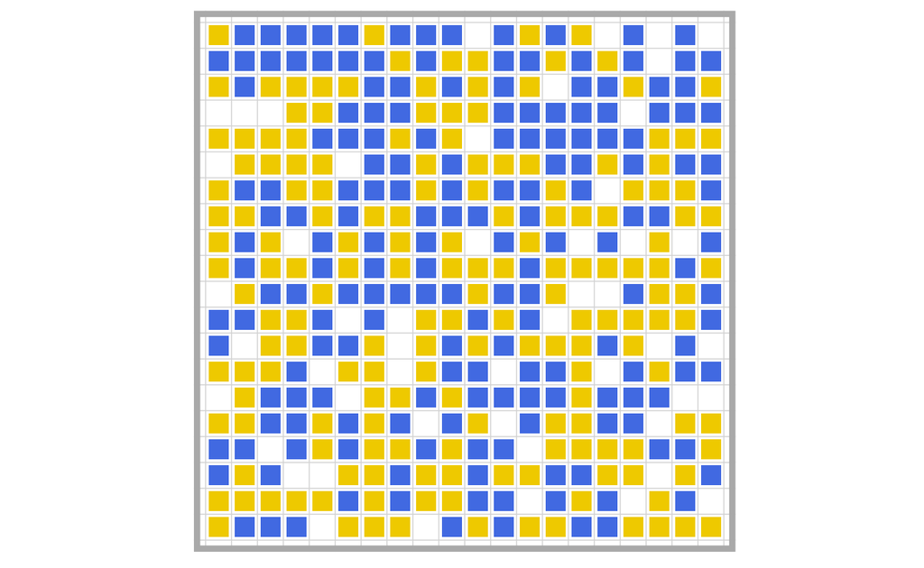

```r
plot_state(
  schelling_board,
  marker_size = 5,
  color_scheme = c("transparent", "gold2", "royalblue")
)
```

The outputs of the `plot_state` function are `ggplot` objects, so you can even theme them further using the functionality of [`ggplot2`](https://ggplot2.tidyverse.org/). For instance, if you would like to plot this board with a dark theme, you can do the following:

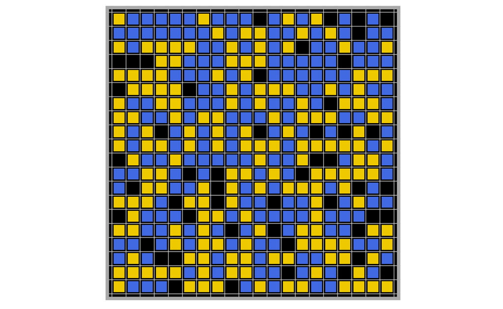

```r
plot_state(
  schelling_board,
  marker_size = 5,
  color_scheme = c("transparent", "gold2", "royalblue")
) +
  theme(panel.background = element_rect(fill = "black"))
```

The same is true for the outputs of `animate_model_run`. They are animations created with the [`gganimate` library](https://gganimate.com/articles/gganimate.html), so they can be modified with `ggplot2` as well.

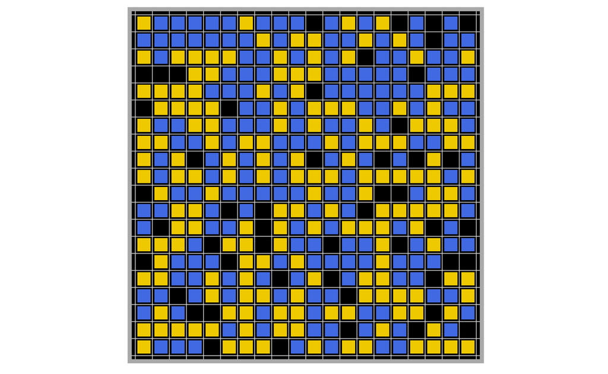

```r
schelling_board %>%
  run_automaton(steps = 100, stepfunc = schelling_step, tolerance = 3) %>%
  animate_model_run(
    marker_size = 5,
    color_scheme = c("transparent", "gold2", "royalblue")
  ) +
    theme(panel.background = element_rect(fill = "black"))
```

## Simulating a Forest Fire

Several well-known cellular automata (or agent-based models, depending on how you view it) are implemented in this package. One of them is the so-called forest fire simulation (Drossel and Schwabl 1992).

Let’s first create a board. The color coding is intended to mimic an actual forest fire: Green cells are trees, orange cells are trees on fire, dark red cells are burnt trees, and white cells are empty. For the forest fire, there is a convenience function `create_forest` because there is a specific way this model is usually setup. You can see in the plot that the trees on the left of the board are all on fire and the rest of the trees are scattered across the board.

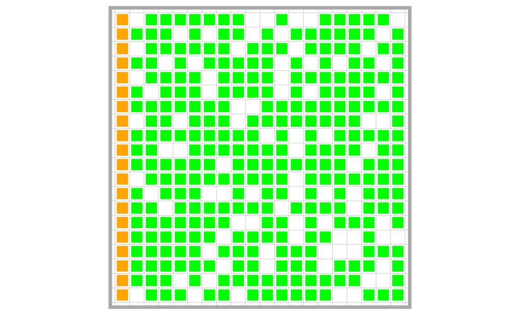

```r
create_forest(axis_size = 20, tree_density = 0.7) %>%
  plot_state(marker_size = 5, color_scheme = theme_forest_fire())
```

In the `create_forest` function, we set a parameter `tree_density`. This is just the probability with which a tree is put on each cell. An example of a sparser forest would look like this:

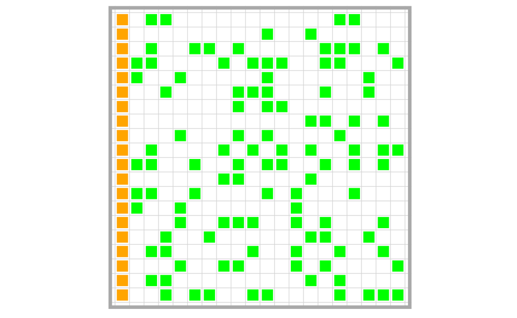

```r
create_forest(axis_size = 20, tree_density = 0.3) %>%
  plot_state(marker_size = 5, color_scheme = theme_forest_fire())
```

… and a more dense one would look like this:

[figure not shown]

```r
create_forest(axis_size = 20, tree_density = 0.9) %>%
  plot_state(marker_size = 5, color_scheme = theme_forest_fire())
```

The stepping function for the forest fire is called `forest_fire_step`. The rule can be summarized s follows:

> Each tree that is on fire sets all its neighboring trees ([Von Neumann neighborhood](https://en.wikipedia.org/wiki/Von_Neumann_neighborhood)) on fire. Each tree on fire transitions into the state “burnt”.

Note that this is a simplified version of the model described by in Drossel and Schwabl (1992).

You can run and animate the automaton like this:

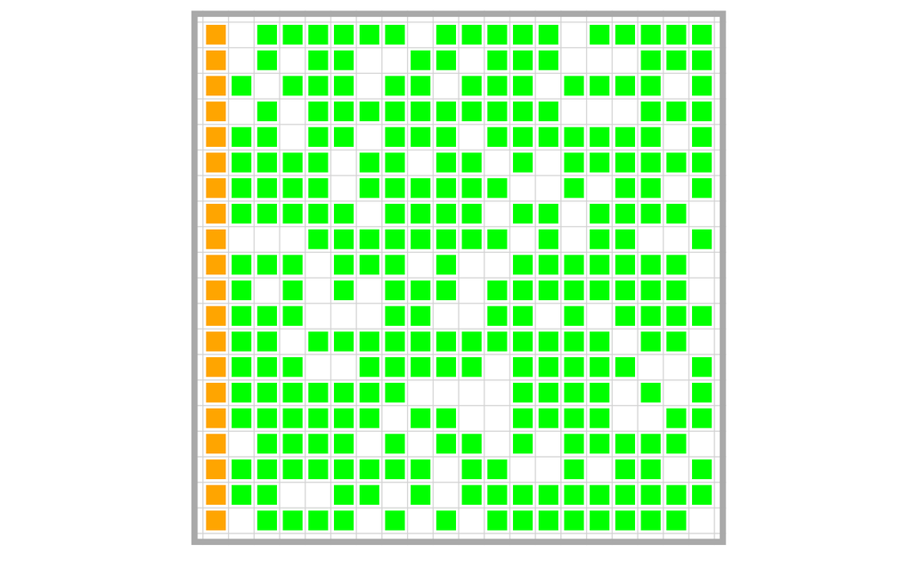

```r
forest <- create_forest(20, 0.7)
forest_results <- run_automaton(forest, 100, forest_fire_step)
animate_model_run(forest_results, 5, theme_forest_fire())
```

As you can see, a wall of fire runs through the forest pretty quickly.

Let’s see, how this looks like in a less dense forest.

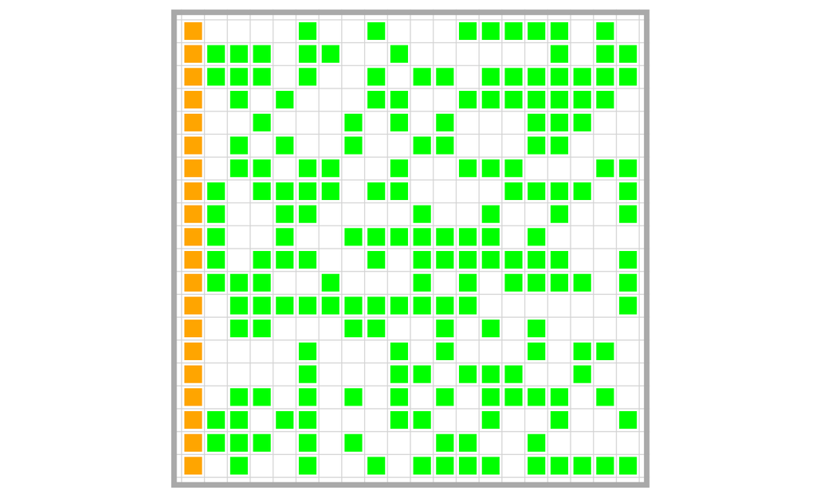

```r
forest <- create_forest(20, 0.5)
forest_results <- run_automaton(forest, 100, forest_fire_step)
animate_model_run(forest_results, 5, theme_forest_fire())
```

Now these animations are nice, but we can go beyond merely looking at the model and analyze the effects of different parameters in-depth. The `run_automaton` function returns a `data.frame` that contains the results of the model run.

```r
forest <- create_forest(20, 0.7)
forest_results <- run_automaton(forest, 100, forest_fire_step)
head(forest_results, 20)
```

| step | cell_id | row | col | state |
| --- | --- | --- | --- | --- |
| 0 | 1 | 20 | 1 | 2 |
| 0 | 2 | 20 | 2 | 0 |
| 0 | 3 | 20 | 3 | 0 |
| 0 | 4 | 20 | 4 | 0 |
| 0 | 5 | 20 | 5 | 1 |
| 0 | 6 | 20 | 6 | 1 |
| 0 | 7 | 20 | 7 | 1 |
| 0 | 8 | 20 | 8 | 1 |
| 0 | 9 | 20 | 9 | 1 |
| 0 | 10 | 20 | 10 | 0 |
| 0 | 11 | 20 | 11 | 0 |
| 0 | 12 | 20 | 12 | 1 |
| 0 | 13 | 20 | 13 | 1 |
| 0 | 14 | 20 | 14 | 1 |
| 0 | 15 | 20 | 15 | 1 |
| 0 | 16 | 20 | 16 | 1 |
| 0 | 17 | 20 | 17 | 1 |
| 0 | 18 | 20 | 18 | 1 |
| 0 | 19 | 20 | 19 | 1 |
| 0 | 20 | 20 | 20 | 0 |

Let’s look how tree density is related to how quickly the fire runs through the forest and how much of the forest is burnt.

```r
# Run 5 replicates of the model
d <- data.frame()
for (density in seq(0.1, 0.9, 0.1)) {
  for (replicate in seq(1, 5, 1)) {
    forest <- create_forest(20, density)
    forest_results <- run_automaton(forest, 100, forest_fire_step)
    forest_results$density <- density
    forest_results$replicate <- replicate
    d <- dplyr::bind_rows(d, forest_results)
  }
}
```

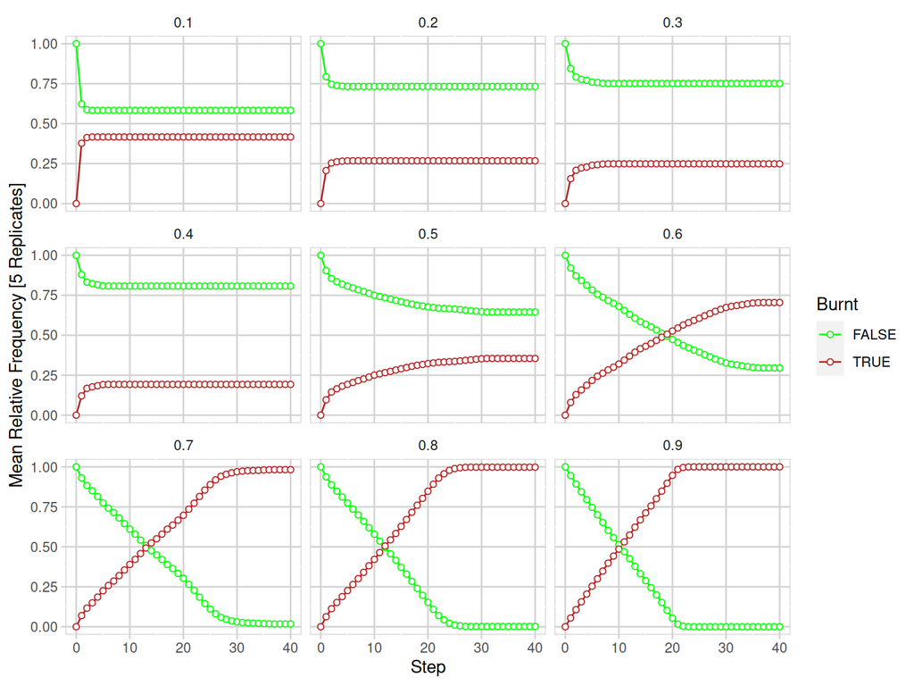

```r
# Format the data and plot the results
d %>%
  filter(step <= 40) %>%
  filter(state %in% c(1, 2, 3)) %>%
  mutate(burnt = factor(state == 3, levels = c(FALSE, TRUE))) %>%
  group_by(density, replicate, step, burnt, .drop = FALSE) %>%
  summarize(count = n()) %>%
  ungroup() %>%
  group_by(density, replicate, step) %>%
  mutate(forest_size = sum(count)) %>%
  ungroup() %>%
  mutate(relfreq = count / forest_size) %>%
  group_by(density, step, burnt) %>%
  summarize(mean_relfreq = mean(relfreq)) %>%
  ungroup() %>%
  ggplot(aes(x = step, y = mean_relfreq, color = burnt)) +
  geom_line() +
  geom_point(shape = 21, fill = "white") +
  scale_y_continuous(breaks = c(0, 0.25, 0.5, 0.75, 1)) +
  scale_color_manual(values = c("green", "firebrick")) +
  facet_wrap(. ~ density, ncol = 3) +
  labs(
    color = "Burnt",
    x = "Step",
    y = "Mean Relative Frequency [5 Replicates]"
  ) +
  theme(
    panel.background = element_rect(fill = "white", color = "lightgrey"),
    strip.background = element_rect(fill = "white", color = "transparent"),
    panel.grid.major.x = element_line(color = "lightgrey"),
    panel.grid.major.y = element_line(color = "lightgrey"),
    axis.ticks = element_line(color = "lightgrey")
  )
```

## Simulating Urban Segregation

A “classic” agent-based model is the Schelling model of urban segregation (Schelling 1971). Schelling demonstrated that even with seemingly high “tolerance” levels in urban areas[^2], stark segregation can occur.

We set up the model with agents of two kinds, let’s call them “orange” and “blue” agents.

[figure not shown]

```r
schelling_board <- matrix(
  sample(c(0, 1, 2), prob = c(0.1, 0.45, 0.45), replace = TRUE, size = 400),
  nrow = 20, ncol = 20
)
plot_state(schelling_board, marker_size = 5, color_scheme = theme_schelling())
```

The update rule is defined as:

> If an agent has more agents of the other kind in its Moore neighborhood than a tolerance parameter $t$, it relocates to a random free position on the board.

This means that if the tolerance level is set to $t = 3$, an orange agent will relocate if it has more than $3$ blue neighbors. Let’s see how this looks like.

[figure not shown]

```r
schelling_board %>%
  run_automaton(steps = 100, stepfunc = schelling_step, tolerance = 3) %>%
  animate_model_run(marker_size = 5, color_scheme = theme_schelling())
```

As you can see, the agents segregate into larger homogeneous areas.

[figure not shown]

```r
schelling_board %>%
  run_automaton(steps = 100, stepfunc = schelling_step, tolerance = 5) %>%
  animate_model_run(marker_size = 5, color_scheme = theme_schelling())
```

If you look at a model run with a tolerance level $t = 5$, we can still observe substantial segregation, even though the agents have an ostensibly high tolerance level.

There are many things that can be analyzed in this model, but I’ll leave this to you. Here are some primers though.

#### Manipulate the Distribution of Agents

For instance, what would happen if the orange agents are the $2:1$ majority? You can control the agent distribution with the `prob` argument in the R base `sample` function.

[figure not shown]

```r
schelling_board <- matrix(
  sample(c(0, 1, 2), prob = c(0.1, 0.60, 0.30), replace = TRUE, size = 400),
  nrow = 20, ncol = 20
)
plot_state(schelling_board, marker_size = 5, color_scheme = theme_schelling())
```

#### Use More Agent Types

In the previous examples, we used two different kinds of agents, but you can use more agent types as well.

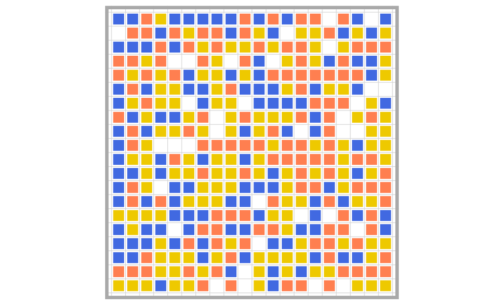

```r
schelling_board <- matrix(
  sample(
    c(0, 1, 2, 3),
    prob = c(0.1, 0.30, 0.30, 0.30),
    replace = TRUE,
    size = 400
  ),
  nrow = 20,
  ncol = 20
)
plot_state(
  schelling_board,
  marker_size = 5,
  color_scheme = c("transparent", "gold2", "royalblue", "coral")
)
```

## Other Rules Implemented in `gridabm`

### Conway’s Life

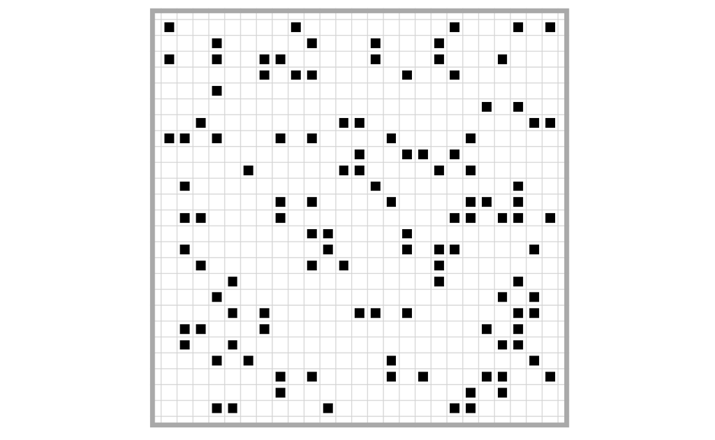

```r
life_board <- matrix(
  sample(c(0, 1), prob = c(0.8, 0.2), replace = TRUE, size = 625),
  nrow = 25, ncol = 25
)
life_results <- run_automaton(life_board, 100, life_step)
animate_model_run(life_results, 3, theme_life())
```

### Brian’s Brain

[figure not shown]

```r
brians_brain_board <- matrix(
  sample(c(0, 1, 2), prob = c(0.5, 0.25, 0.25), replace = TRUE, size = 2500),
  nrow = 50, ncol = 50
)
brians_brain_results <- run_automaton(
  brians_brain_board,
  200,
  brians_brain_step
)
animate_model_run(brians_brain_results, 2, theme_brians_brain_dark()) +
  theme(
    panel.background = element_rect(fill = "black"),
    panel.grid.major = element_line(color = "black"),
    panel.grid.minor = element_line(color = "black")
  )
```

Drossel, B., and F. Schwabl. 1992. “Self-Organized Critical Forest-Fire Model.” *Phys. Rev. Lett.* 69 (September): 1629–32. https://doi.org/10.1103/PhysRevLett.69.1629.

Schelling, Thomas C. 1971. “Dynamic Models of Segregation.” *The Journal of Mathematical Sociology* 1 (2): 143–86. https://doi.org/10.1080/0022250X.1971.9989794.

[^1]: Currently, only square grids are possible, so the two dimensions of the grid are identical
[^2]: Tolerance meaning how many agents of a different color an agent is willing to live next to.